# Лабораторная работа №4. Гармонический осциллятор

Вариант 38

Автор

принадлежность

Амина Накова

Российский университет дружбы народов

Аннотация

Исследуется линейный гармонический осциллятор в трёх режимах: без затухания и внешней силы, с затуханием, с затуханием и внешней силой. Для каждого случая строится решение уравнения и фазовый портрет. Параметры заданы согласно варианту 38.

Ключевые слова

математическое моделирование, гармонический осциллятор, фазовый портрет, Julia

# 1 Введение

## 1.1 Актуальность

Модель гармонического осциллятора описывает колебания в самых разных физических системах: грузик на пружине, математический маятник, заряд в электрическом контуре, а также множество процессов в физике, химии и биологии.

## 1.2 Цель работы

Построить решения уравнения гармонического осциллятора и его фазовые портреты для трёх случаев, предусмотренных заданием (вариант 38).

## 1.3 Задачи

1. Решить уравнение гармонического осциллятора без затухания.
2. Решить уравнение с затуханием.
3. Решить уравнение с затуханием и внешней силой.
4. Построить фазовые портреты для каждого случая.

## 1.4 Методы исследования

Численное интегрирование систем ОДУ методом `Tsit5()`, визуализация средствами `Plots.jl`.

# 2 Теоретическая часть

## 2.1 Основная модель

Уравнение свободных колебаний гармонического осциллятора:

$$\ddot{x} + 2\gamma\dot{x} + \omega_0^2 x = 0$$

где $\gamma$ — параметр потерь, $\omega_0$ — собственная частота.

## 2.2 Переход к системе первого порядка

Уравнение второго порядка сводится к системе:

$$\begin{cases} \dot{x} = y \\ \dot{y} = -\omega_0^2 x - 2\gamma y + f(t) \end{cases}$$

## 2.3 Фазовый портрет

Точки $(x, y)$ образуют фазовую плоскость. Кривые на ней — фазовые траектории; их совокупность — фазовый портрет.

## 2.4 Параметры варианта 38

- Начальные условия: $x_0 = 1.2$, $y_0 = -1.2$
- Время: $t \in [0; 72]$
- Случай 1: $\ddot{x} + 21x = 0$
- Случай 2: $\ddot{x} + 2.2\dot{x} + 2.3x = 0$
- Случай 3: $\ddot{x} + 2.4\dot{x} + 2.5x = 0.2\sin(2.6t)$

# 3 Материалы и методы

Работа выполнена на языке Julia 1.13 с пакетами:

- `DifferentialEquations.jl` — решение ОДУ
- `Plots.jl` — визуализация
- `DrWatson.jl` — организация проекта
- `Literate.jl` — литературное программирование

# 4 Выполнение лабораторной работы

## 4.1 Случай 1: без затухания и без внешней силы

Решение уравнения:

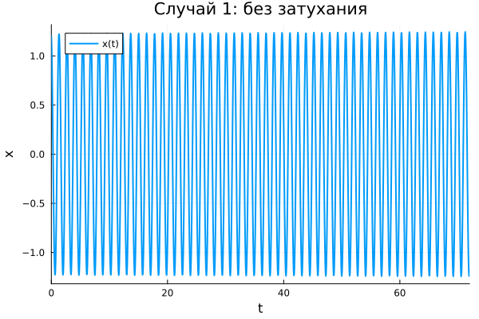

Рисунок 1: Решение: без затухания

Фазовый портрет:

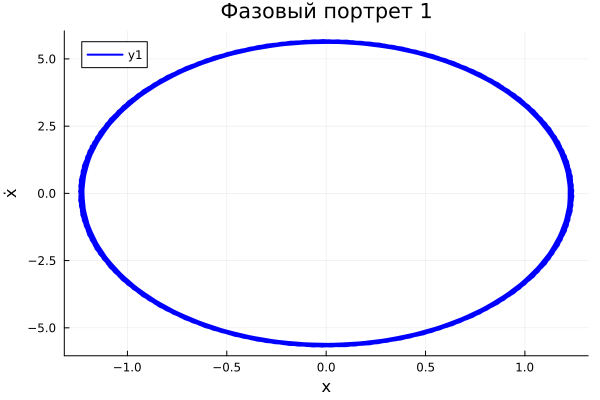

Рисунок 2: Фазовый портрет 1

Фазовый портрет — эллипс: энергия сохраняется.

## 4.2 Случай 2: с затуханием, без внешней силы

Решение уравнения:

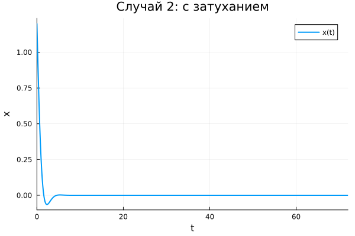

Рисунок 3: Решение: с затуханием

Фазовый портрет:

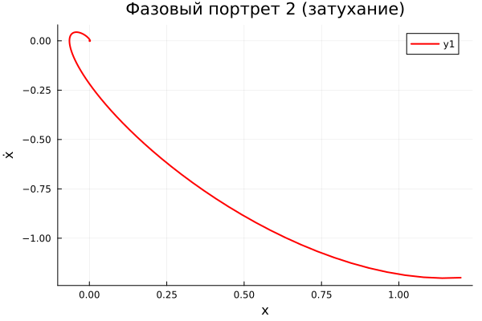

Рисунок 4: Фазовый портрет 2

Фазовый портрет — скручивающаяся спираль: колебания затухают.

## 4.3 Случай 3: с затуханием и внешней силой

Решение уравнения:

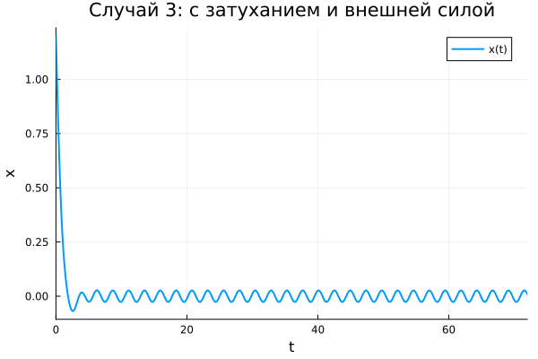

Рисунок 5: Решение: с внешней силой

Фазовый портрет:

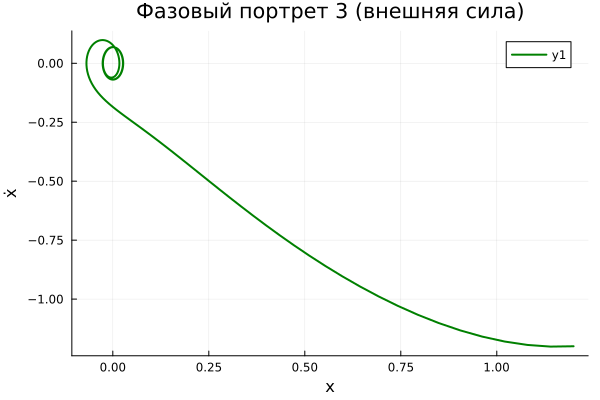

Рисунок 6: Фазовый портрет 3

При наличии внешней силы решение выходит на установившийся режим вынужденных колебаний.

## 4.4 Сводный график

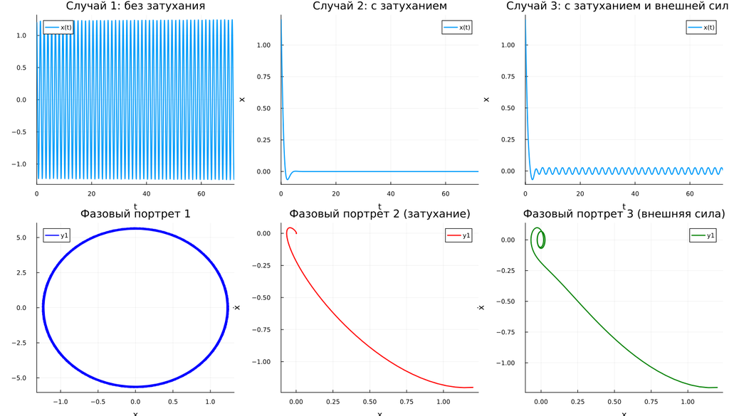

Рисунок 7: Сводный график

# 5 Результаты

- Случай 1: амплитуда постоянна, энергия сохраняется.
- Случай 2: амплитуда убывает, колебания затухают.
- Случай 3: устанавливается режим вынужденных колебаний.

# 6 Обсуждение результатов

Результаты полностью соответствуют теории:

- фазовый портрет без затухания — замкнутая кривая;
- с затуханием — сходящаяся спираль;
- с внешней силой — установившиеся колебания.

# 7 Заключение

- Решены три задачи о гармоническом осцилляторе.
- Построены решения и фазовые портреты.
- Проведён анализ поведения системы в каждом случае.

# Список литературы